# Series_UNAM_class_28_Feb_2023

Sergibar

2023-02-28

# Suavizamiento de series de tiempo con Holt Winters

## Serie 3

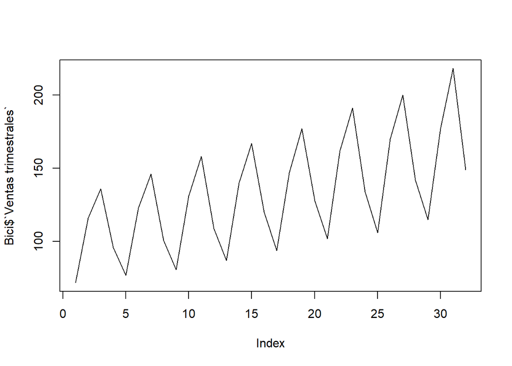

```r
library(readxl)
Bici <- read_excel("SeriesHW.xlsx", sheet = "Bicicletas")
#View(Bici)

plot(Bici$`Ventas trimestrales`, type="l")
```

```r
bici <-Bici$'Ventas trimestrales'
```

Teniendo la tendencia, que sería la recta que mejor representa a dischos datos

```r
tendencia <-lm(bici~c(1:32))
tendencia
```

```
##
## Call:
## lm(formula = bici ~ c(1:32))
##
## Coefficients:
## (Intercept)      c(1:32)
##      95.631        2.295
```

Esta ya sería la recta de nuestros datos

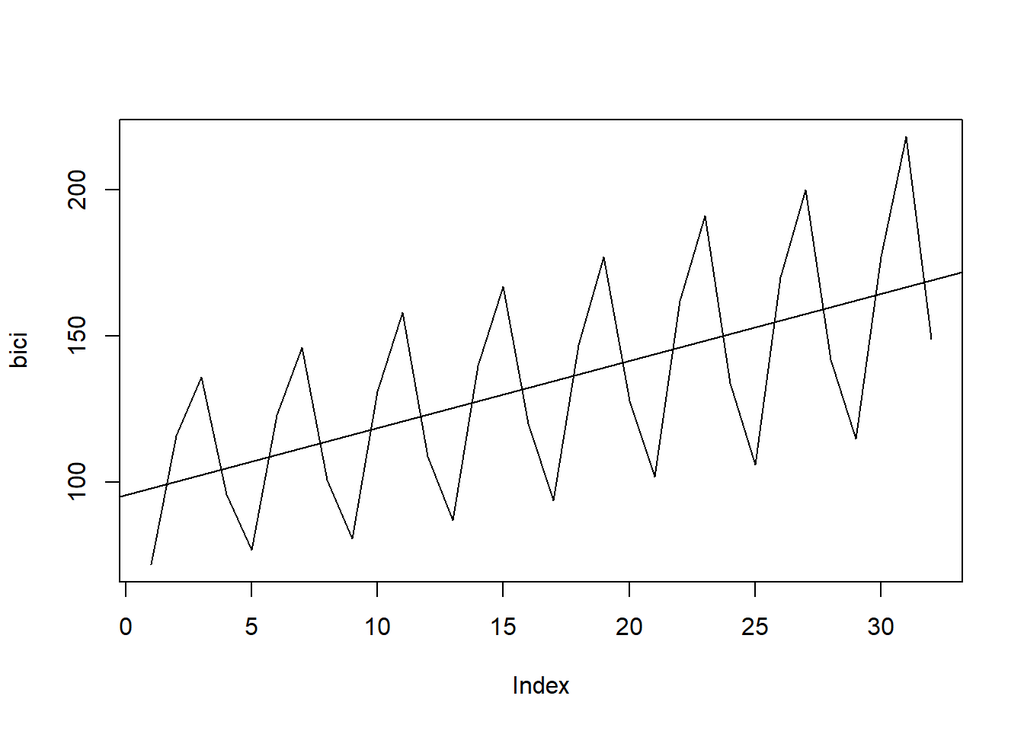

```r
recta_3 <- tendencia$coefficients[1] + c(1:32)*tendencia$coefficients[2]

plot(bici, type='l')
abline(tendencia)
```

Vamos a reover tendencia

```r
bici_st <- bici/recta_3
bici_st
```

```
##  [1] 0.7352480 1.1574395 1.3266181 0.9159309 0.7189107 1.1242982 1.3071116
##  [8] 0.8860290 0.6965535 1.1047215 1.3071137 0.8849406 0.6934084 1.0957851
## [15] 1.2840487 0.9066700 0.6981189 1.0734422 1.2712073 0.9043840 0.7091809
## [22] 1.1086552 1.2869053 0.8891062 0.6927731 1.0946320 1.2690482 0.8880911
## [29] 0.7090511 1.0760946 1.3071208 0.8812716
```

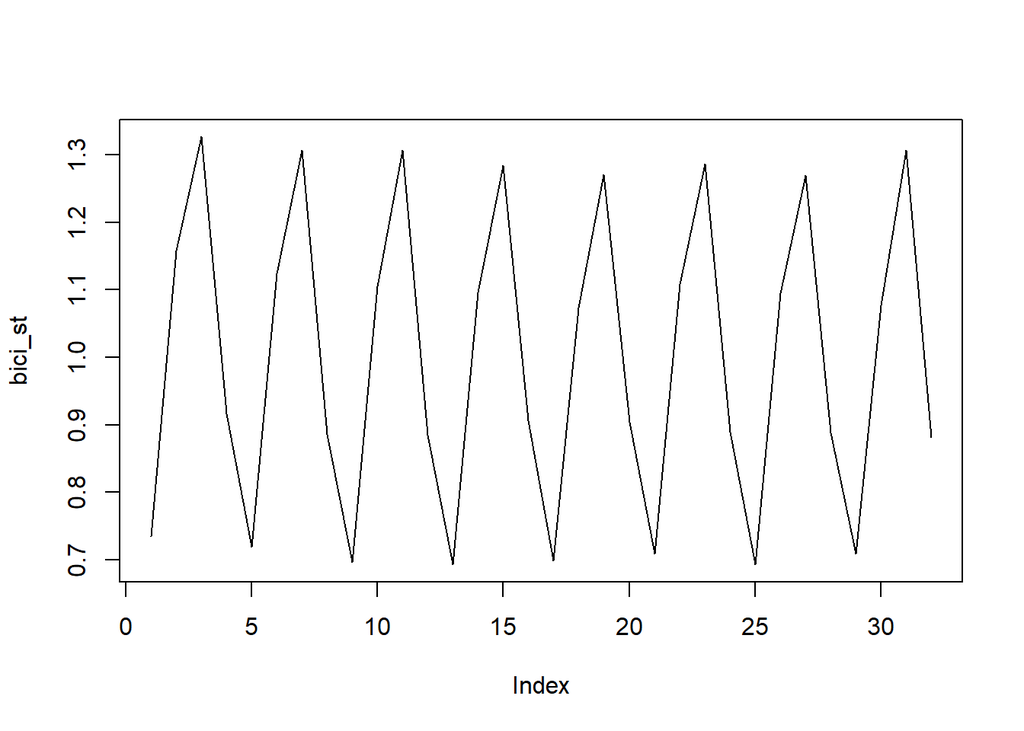

```r
plot(bici_st, type='l')
```

2. Después se remueve la estacionalidad Hay que calcular los factores estacionales, por ejemplo, filtrando los factores que corresponden a los trimestres (1,2,3 y 4) vs el promedio de toda la seria

TOMANDO SOLO LOS TRIMESTRES DE LA SERIE

```r
trimestre1 <-bici_st[seq(1,32, by=4)]
trimestre1
```

```
## [1] 0.7352480 0.7189107 0.6965535 0.6934084 0.6981189 0.7091809 0.6927731
## [8] 0.7090511
```

```r
trimestre2 <-bici_st[seq(2,32, by=4)]
trimestre2
```

```
## [1] 1.157439 1.124298 1.104721 1.095785 1.073442 1.108655 1.094632 1.076095
```

```r
trimestre3 <-bici_st[seq(3,32, by=4)]
trimestre3
```

```
## [1] 1.326618 1.307112 1.307114 1.284049 1.271207 1.286905 1.269048 1.307121
```

```r
trimestre4 <-bici_st[seq(4,32, by=4)]
trimestre4
```

```
## [1] 0.9159309 0.8860290 0.8849406 0.9066700 0.9043840 0.8891062 0.8880911
## [8] 0.8812716
```

¿Cómo está el trimestre 1 vs todos los datos? (Factor estacional 1)

```r
FE1 <-mean(trimestre1) / mean(bici_st)
FE1
```

```
## [1] 0.7065692
```

Otros factores estacionales

```r
FE2 <-mean(trimestre2) / mean(bici_st)
FE2
```

```
## [1] 1.104249
```

```r
FE3 <-mean(trimestre3) / mean(bici_st)
FE3
```

```
## [1] 1.294739
```

```r
FE4 <-mean(trimestre4) / mean(bici_st)
FE4
```

```
## [1] 0.8944436
```

SI NO HUBIERA ESTACIONALIDAD, LOS PROMEDIOS, DEBE´RIA TENDER A UNO. PERO EN ESTE CASO

FE_1 = 0.7 Y FE=1.10

ADEMÁS ESTO ESTÁ AFECTADO POR LA TENDENCIA QUE EN GENERAL SE INCRMEENTA 2.29 NICICLETAS “CADA TRIMESTRE”

Ahora lo que prentendemos es llevar cada valor de la serie los más parecida a 1 posible

```r
bici_ruido <- bici_st /c(FE1, FE2, FE3, FE4)
bici_ruido
```

```
##  [1] 1.0405888 1.0481693 1.0246224 1.0240230 1.0174667 1.0181568 1.0095564
##  [8] 0.9905923 0.9858248 1.0004282 1.0095580 0.9893755 0.9813735 0.9923355
## [15] 0.9917437 1.0136692 0.9880404 0.9721019 0.9818255 1.0111134 1.0036963
## [22] 1.0039905 0.9939499 0.9940326 0.9804745 0.9912913 0.9801579 0.9928977
## [29] 1.0035125 0.9745039 1.0095635 0.9852735
```

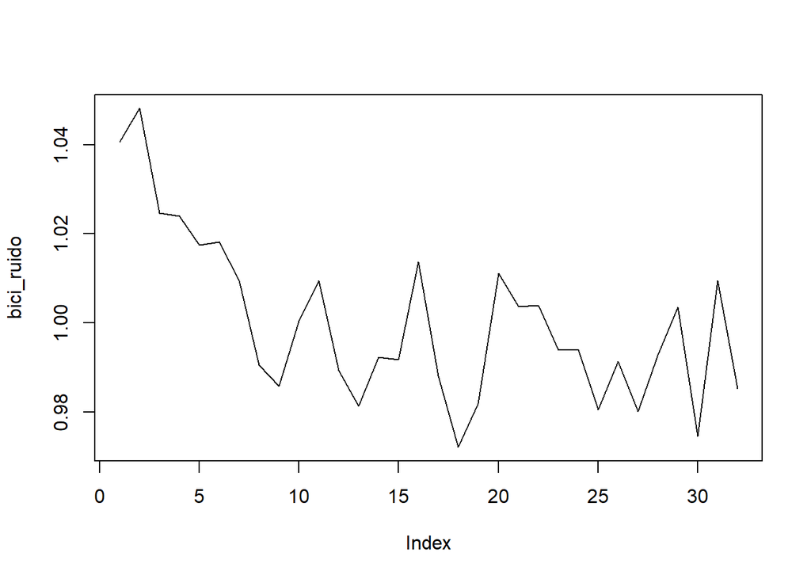

```r
plot(bici_ruido, type='l')
```

Si se medio acercan los valores en estacionalidad a 1 (NO ES exactamente UNO por el ‘ruido / componente netamente estocástico que tiene y que nosotros suponemos que se comporta normalmente’)

Ahora vamos a filtrar el ruido

Los valores en filtro_ruido_bici deben estar ‘muy cercanos a cero’, pues los desmediamos

```r
filtro_ruido_bici <- bici_ruido - mean(bici_ruido)

filtro_ruido_bici
```

```
##  [1]  0.0404666184  0.0480471016  0.0245002682  0.0239008664  0.0173445449
##  [6]  0.0180346400  0.0094342196 -0.0095298397 -0.0142974257  0.0003060324
## [11]  0.0094358552 -0.0107466642 -0.0187486407 -0.0077866882 -0.0083784949
## [16]  0.0135470470 -0.0120818149 -0.0280202468 -0.0182967035  0.0109912243
## [21]  0.0035741005  0.0038683700 -0.0061722312 -0.0060895421 -0.0196477016
## [26] -0.0088309138 -0.0199642458 -0.0072244348  0.0033903191 -0.0256182952
## [31]  0.0094413324 -0.0148486569
```

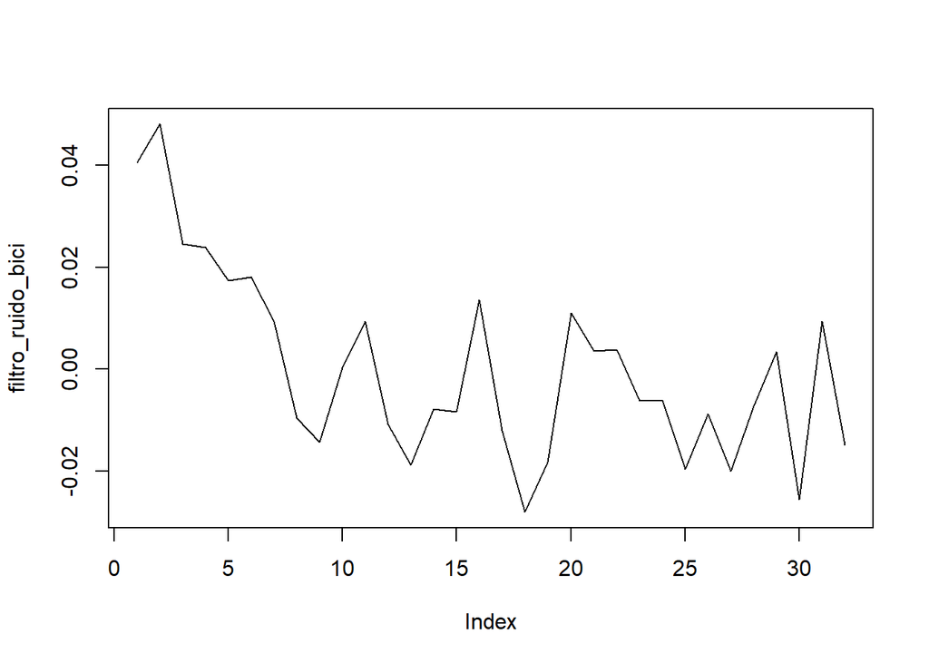

```r
plot(filtro_ruido_bici, type='l')
```

AHORA AL MOMENTO NUESTRO VALOR PRONOSTICADO PARA EL SIGUIENTE TRIMESTRE (Y DE HECHO PARA LOS SIG 4 PERIODOS ES LA MEDIA)

```r
bici_pronosticado <- mean(bici_ruido)
bici_pronosticado
```

```
## [1] 1.000122
```

Ahora construimos el valor de los 32 NAs + los 4 pronosticos

```r
bici_pronostico <- c(rep(NA,32),rep(bici_pronosticado,4))
bici_pronostico
```

```
##  [1]       NA       NA       NA       NA       NA       NA       NA       NA
##  [9]       NA       NA       NA       NA       NA       NA       NA       NA
## [17]       NA       NA       NA       NA       NA       NA       NA       NA
## [25]       NA       NA       NA       NA       NA       NA       NA       NA
## [33] 1.000122 1.000122 1.000122 1.000122
```

AHORA PARA TENER LOS 32 DATOS COMO TAL + EL PRONOSTICO

```r
bici_pronostico_2 <- c(bici_ruido,rep(bici_pronosticado,4))
bici_pronostico_2
```

```
##  [1] 1.0405888 1.0481693 1.0246224 1.0240230 1.0174667 1.0181568 1.0095564
##  [8] 0.9905923 0.9858248 1.0004282 1.0095580 0.9893755 0.9813735 0.9923355
## [15] 0.9917437 1.0136692 0.9880404 0.9721019 0.9818255 1.0111134 1.0036963
## [22] 1.0039905 0.9939499 0.9940326 0.9804745 0.9912913 0.9801579 0.9928977
## [29] 1.0035125 0.9745039 1.0095635 0.9852735 1.0001222 1.0001222 1.0001222
## [36] 1.0001222
```

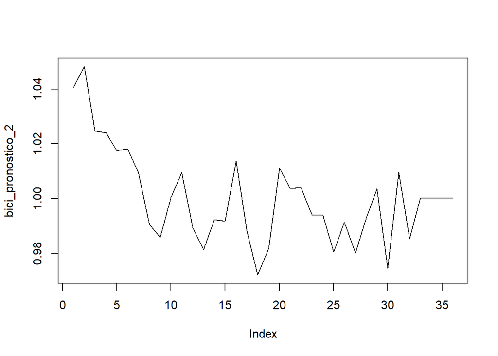

```r
plot(bici_pronostico_2, type='l')
```

AHORA, como generamos los INTERVALOS DE CONFIANZA

Entonces a la media que es el ronostico se le debe restar 2 veces la desviación estandar de los errores (Desviación estandar del ruido) * la raíz del determinado periodo

```r
LI <-bici_pronostico_2[33:36] - 2*sd(filtro_ruido_bici)*c(1:4)^.5
LI
```

```
## [1] 0.9635247 0.9483655 0.9367334 0.9269271
```

LI obviamente va disminuyendo

El limite superior es ‘como el inferior pero sumando el error’

```r
LS <-bici_pronostico_2[33:36] + 2*sd(filtro_ruido_bici)*c(1:4)^.5
LS
```

```
## [1] 1.036720 1.051879 1.063511 1.073317
```

LS obviamente va creciendo

Ahora construimos el valor de los 32 NAs + los 4 pronosticos

```r
LI2 <- c(rep(NA, times=32),LI)
LI2
```

```
##  [1]        NA        NA        NA        NA        NA        NA        NA
##  [8]        NA        NA        NA        NA        NA        NA        NA
## [15]        NA        NA        NA        NA        NA        NA        NA
## [22]        NA        NA        NA        NA        NA        NA        NA
## [29]        NA        NA        NA        NA 0.9635247 0.9483655 0.9367334
## [36] 0.9269271
```

```r
LS2 <- c(rep(NA, times=32),LS)
LS2
```

```
##  [1]       NA       NA       NA       NA       NA       NA       NA       NA
##  [9]       NA       NA       NA       NA       NA       NA       NA       NA
## [17]       NA       NA       NA       NA       NA       NA       NA       NA
## [25]       NA       NA       NA       NA       NA       NA       NA       NA
## [33] 1.036720 1.051879 1.063511 1.073317
```

VAMOS A ‘DEVOLVER ESTACIONALIDAD MULTIPLICANDO POR LOS FACTORES DE ESTACIONALIDAD’

```r
bici_cest <- bici_pronostico_2 *c(FE1,FE2,FE3,FE4)
bici_cest
```

```
##  [1] 0.7352480 1.1574395 1.3266181 0.9159309 0.7189107 1.1242982 1.3071116
##  [8] 0.8860290 0.6965535 1.1047215 1.3071137 0.8849406 0.6934084 1.0957851
## [15] 1.2840487 0.9066700 0.6981189 1.0734422 1.2712073 0.9043840 0.7091809
## [22] 1.1086552 1.2869053 0.8891062 0.6927731 1.0946320 1.2690482 0.8880911
## [29] 0.7090511 1.0760946 1.3071208 0.8812716 0.7066556 1.1043835 1.2948967
## [36] 0.8945529
```

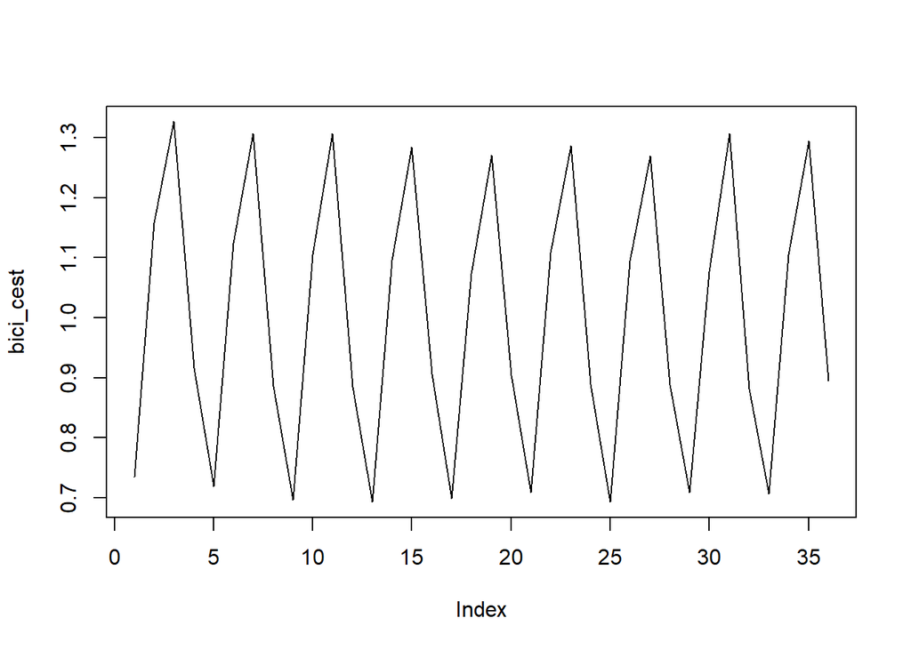

```r
plot(bici_cest, type='l')
```

Ahora vamos a agregar los limites

```r
LI_cest <- LI2*c(FE1,FE2,FE3,FE4)
LI_cest
```

```
##  [1]        NA        NA        NA        NA        NA        NA        NA
##  [8]        NA        NA        NA        NA        NA        NA        NA
## [15]        NA        NA        NA        NA        NA        NA        NA
## [22]        NA        NA        NA        NA        NA        NA        NA
## [29]        NA        NA        NA        NA 0.6807969 1.0472312 1.2128248
## [36] 0.8290841
```

```r
LS_cest <- LS2*c(FE1,FE2,FE3,FE4)
LS_cest
```

```
##  [1]        NA        NA        NA        NA        NA        NA        NA
##  [8]        NA        NA        NA        NA        NA        NA        NA
## [15]        NA        NA        NA        NA        NA        NA        NA
## [22]        NA        NA        NA        NA        NA        NA        NA
## [29]        NA        NA        NA        NA 0.7325143 1.1615358 1.3769686
## [36] 0.9600218
```

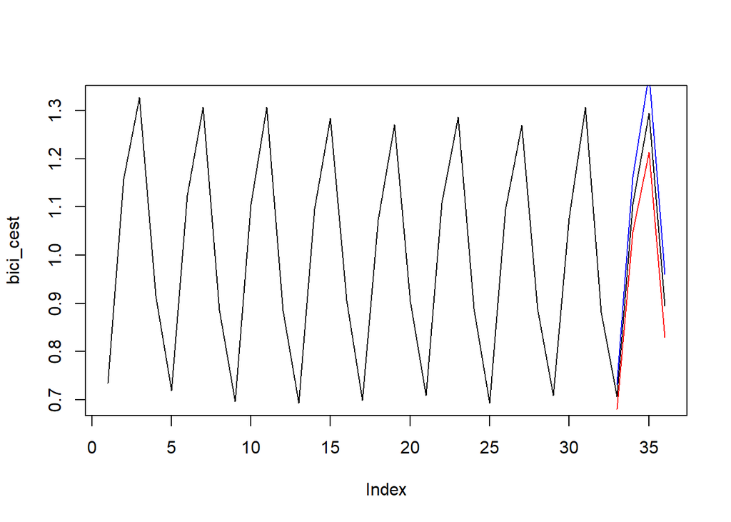

```r
plot(bici_cest, type='l')
lines(LI_cest, col='red')
lines(LS_cest, col='blue')
```

Ahora solo falta ‘devolver tendencia’